# Lab 9. Planning

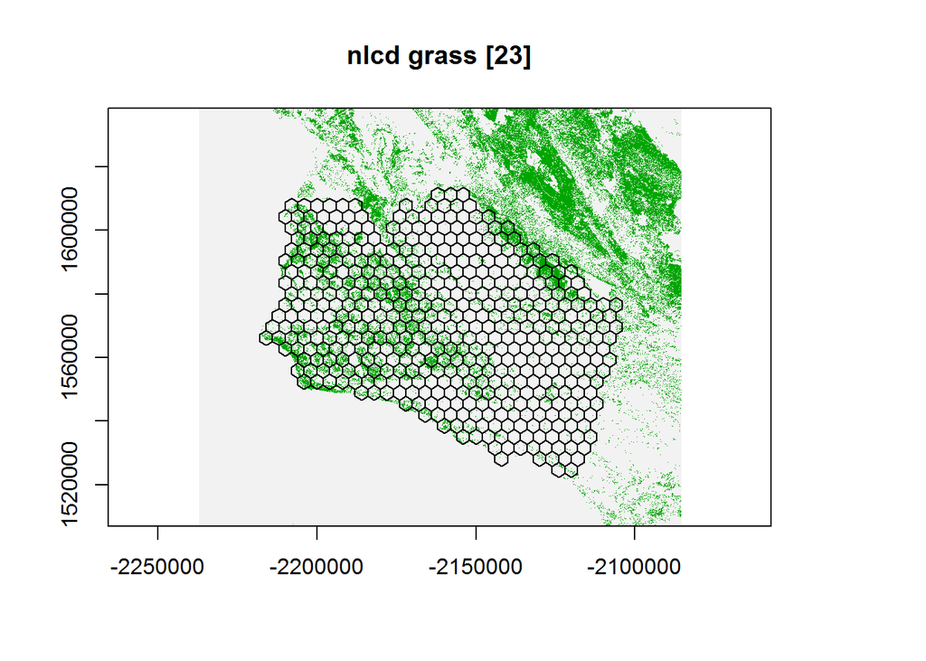

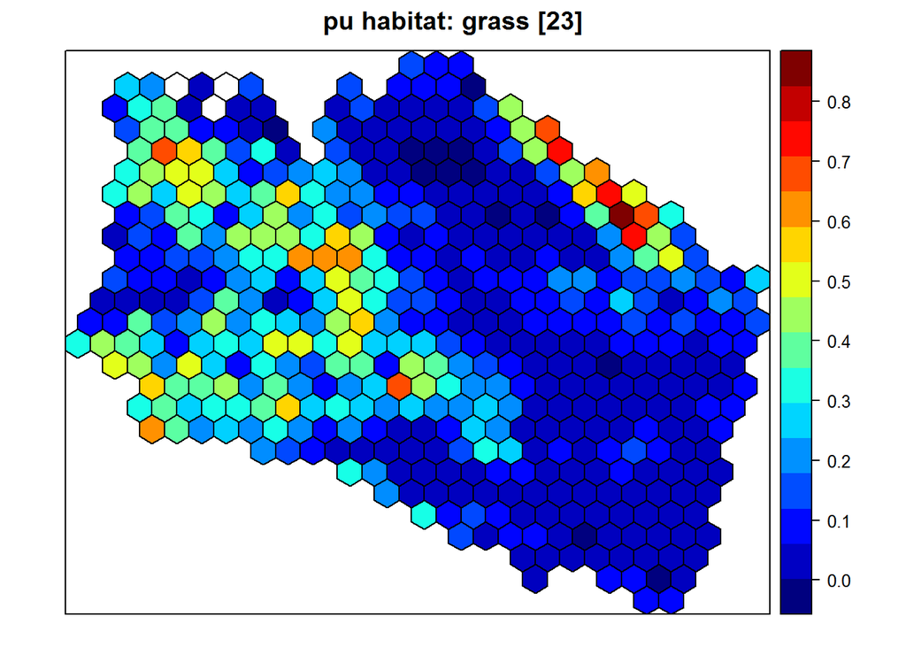

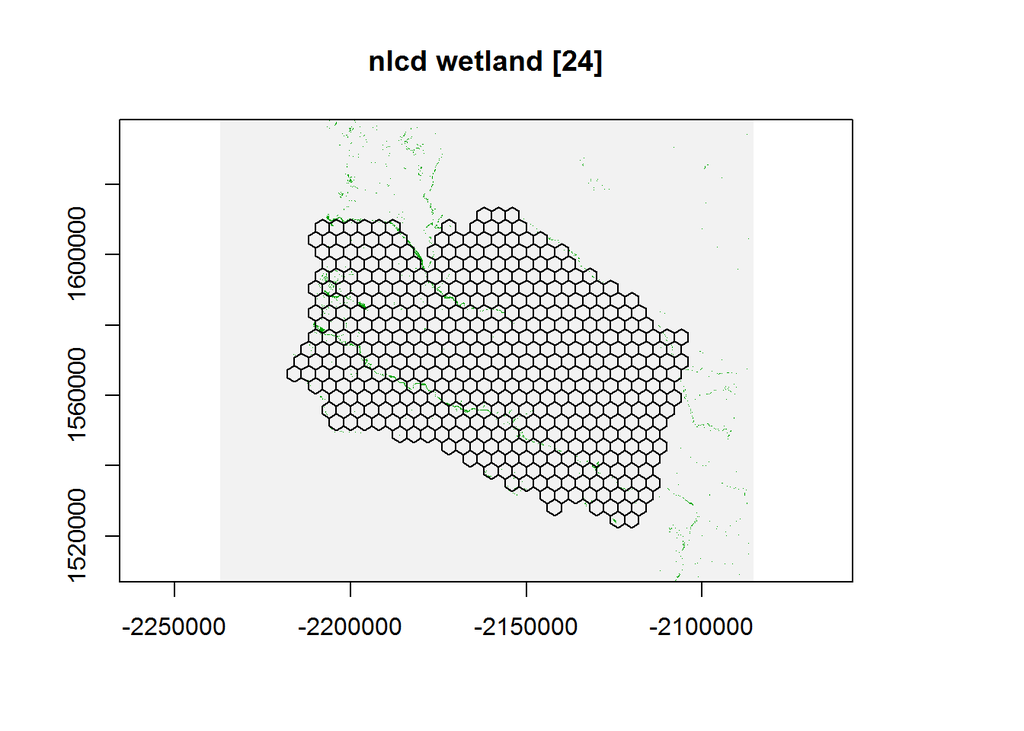

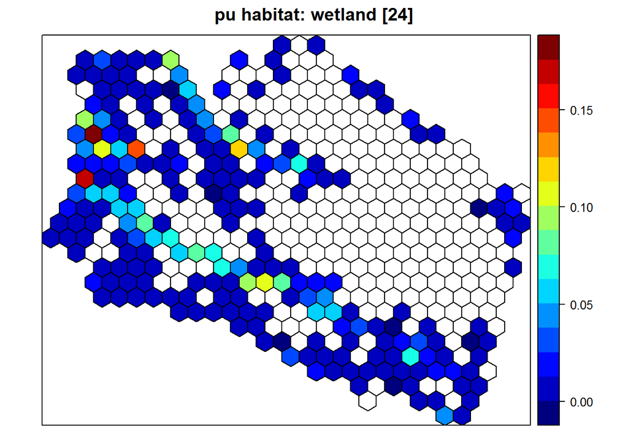

Here’s a summary of proportion of habitat across planning units:

| habitat | n | min | mean | max | sum |
| --- | --- | --- | --- | --- | --- |
| forest | 440 | 0.0003253 | 0.2564760 | 0.9056189 | 112.849460 |
| grass | 470 | 0.0003253 | 0.1676349 | 0.8264151 | 78.788415 |
| shrub | 469 | 0.0002589 | 0.4295811 | 0.9662980 | 201.473558 |
| wetland | 222 | 0.0000647 | 0.0181315 | 0.1758621 | 4.025182 |

Besides the habitat amounts extracted per planning unit (ie `pu_vs_spp.csv`), we need to append these habitats into the conservation features file (ie `spp.csv`) with explicit target amounts and species penalty factors (spf) for Marxan to use in its analysis:

| id | target | spf | name |
| --- | --- | --- | --- |
| 21 | 50 | 40 | forest |
| 22 | 20 | 20 | shrub |
| 23 | 20 | 20 | grass |
| 24 | 2 | 20 | wetland |

```
## [1] "Marxan output file not found: scenario_06/output/out_best.txt"
```

**Question**: Based on these additional conservation features, how do you expect the scenario_06 results to differ from scenario_05 and do you see any evidence of this in the output?

# Assignment

Answer the questions above and be sure to include all your scenario_# best and ssoln output figures in your writeup.